Lake Name: Cazenovia Lake

Lake acreage: 1164.78194168

County: MADISON

PWLID: 0703-0021

Waterbody Classification: A

Coordinates: 42.970031,-75.879227

Is this waterbody a public water supply: No

Are there DOH desingated beaches on this waterbody: Yes

Open Water Indicators

2018 Sampling Results

Seasonal Change

06-10

06-19

07-07

07-17

07-29

08-19

09-02

09-13

Clarity (m)

4.50

4.00

4.50

5.00

4.50

3.50

3.50

3.50

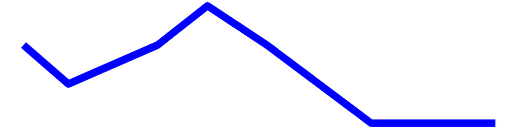

Surface TP (mg/L)

0.01

0.01

0.01

0.02

0.01

0.01

0.01

0.01

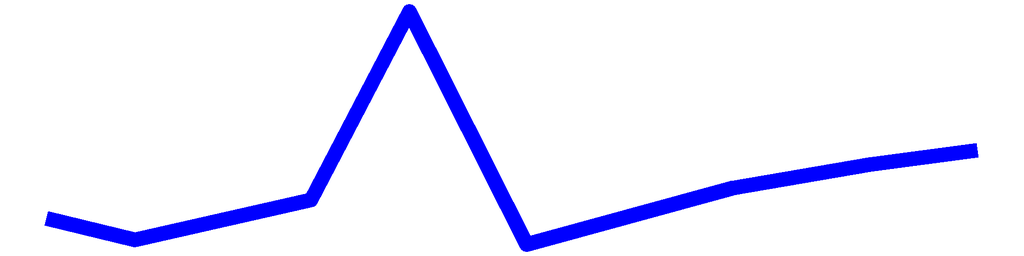

Surface TDP (mg/L)

0.00

0.01

0.01

0.01

0.01

0.01

0.01

0.00

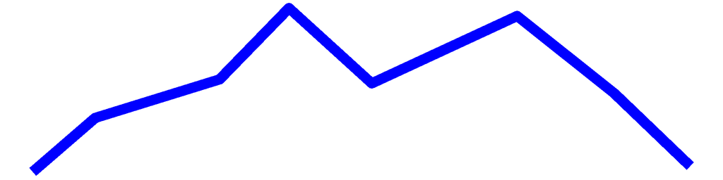

Deep TP (mg/L)

0.02

0.02

0.02

0.02

0.02

0.03

0.05

0.08

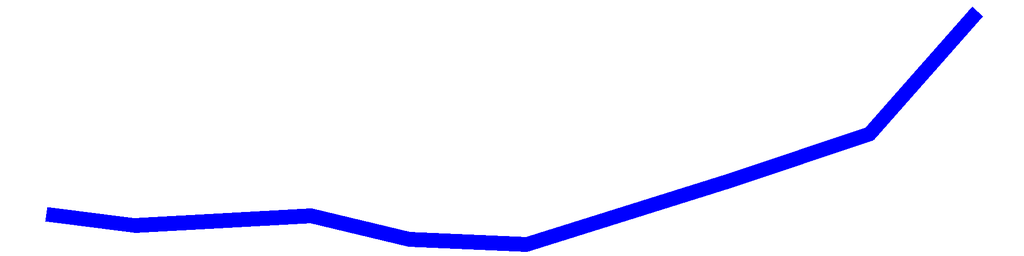

Deep TDP (mg/L)

0.00

0.01

0.01

0.01

0.01

0.02

0.02

0.03

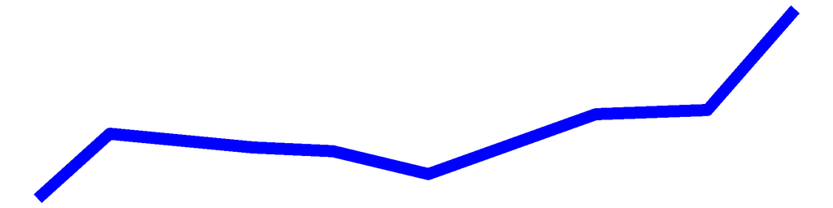

TN (mg/L)

0.36

0.41

0.43

0.41

0.46

0.38

0.45

0.38

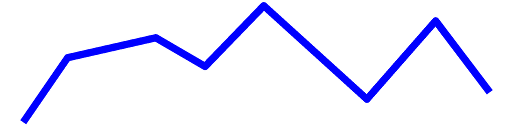

TDN (mg/L)

0.38

0.41

0.40

0.46

0.42

0.36

0.44

0.42

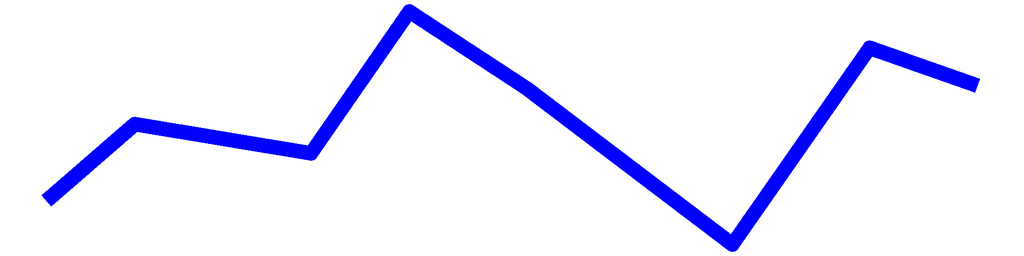

TN:TP

30.11

37.67

33.99

19.65

42.53

28.66

31.43

25.97

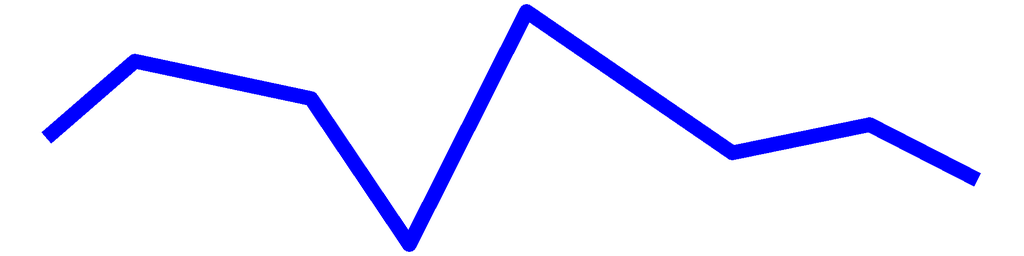

Surface NH3 (mg/L)

0.02

0.00

0.06

0.03

0.02

0.03

0.12

0.17

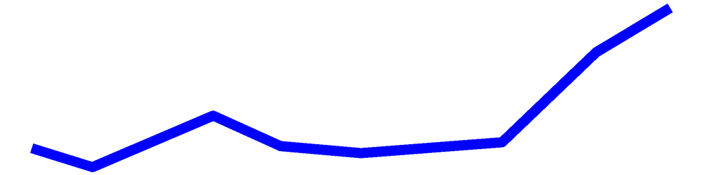

Deep NH3 (mg/L)

0.10

0.02

0.12

0.03

0.06

0.07

0.06

0.25

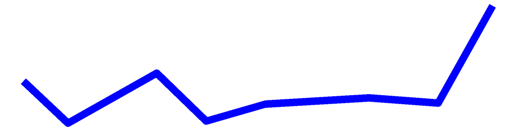

Chl.a (ug/L)

2.90

4.10

1.40

1.80

1.70

3.70

2.00

2.40

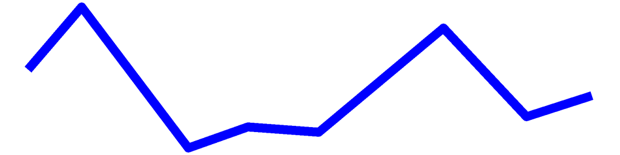

pH

7.00

7.62

7.54

7.66

7.59

7.50

7.17

7.86

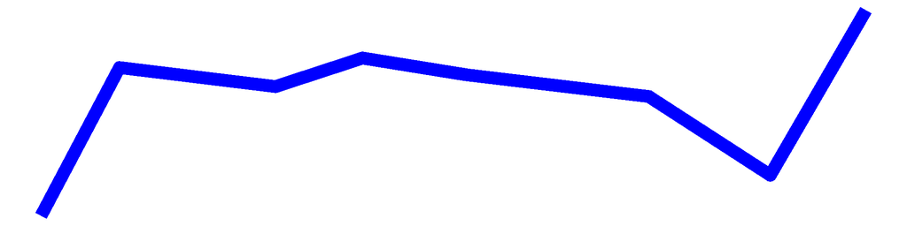

Cond (umho/cm)

308.00

204.40

265.50

306.50

209.80

282.30

285.10

265.60

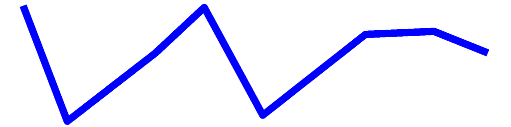

Surface Calcium (mg/L)

Bottom Calcium (mg/L)

Surface Chloride (mg/L)

28.40

30.40

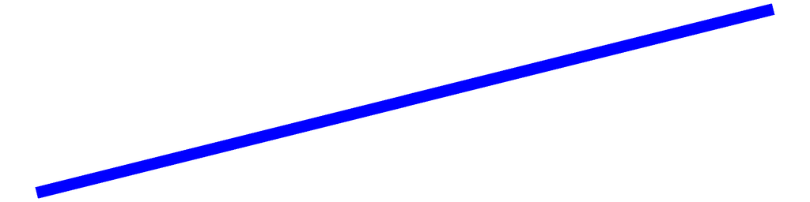

Bottom Chloride (mg/L)

Upper Temp (degC)

20.00

24.00

24.00

26.00

24.00

24.00

24.00

22.00

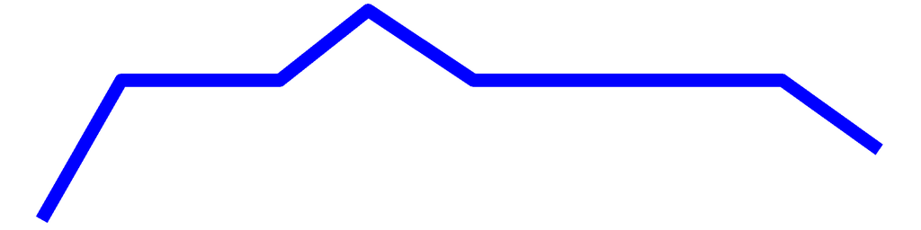

Deep Temp (degC)

12.00

14.00

13.00

16.00

15.00

14.00

15.00

16.00

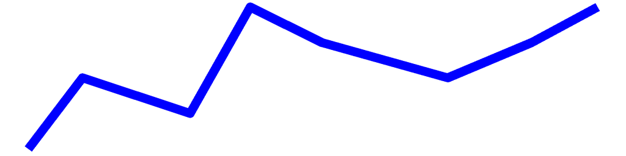

FP BG Chl.a (ug/L)

1.60

2.70

1.40

1.38

1.42

3.04

3.17

3.18

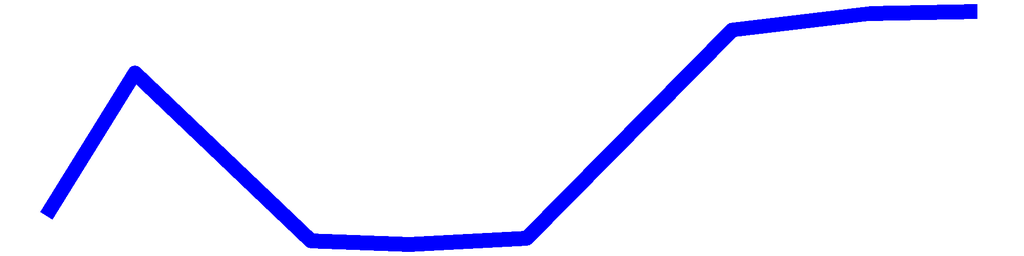

## Cazenovia Lake – Sampling Season Results

### HABs Status

#### Open Water Algae

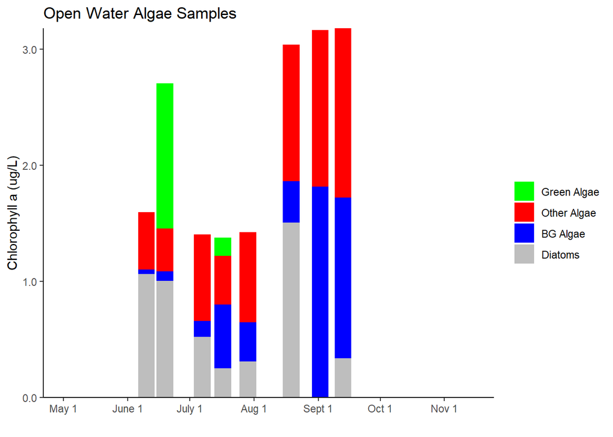

#### Shoreline Algae

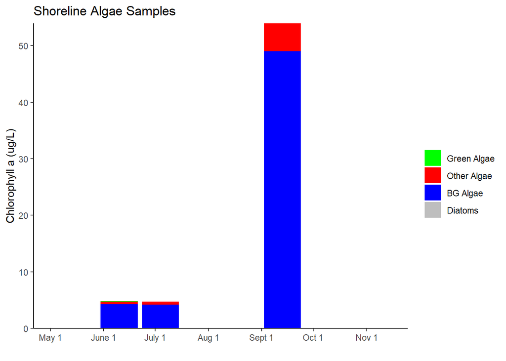

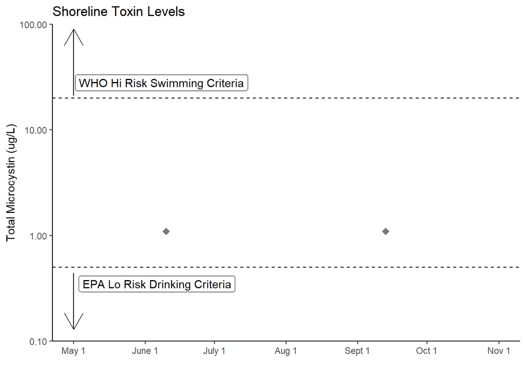

## Cazenovia Lake Long-Term Trend Analysis

#### Clarity

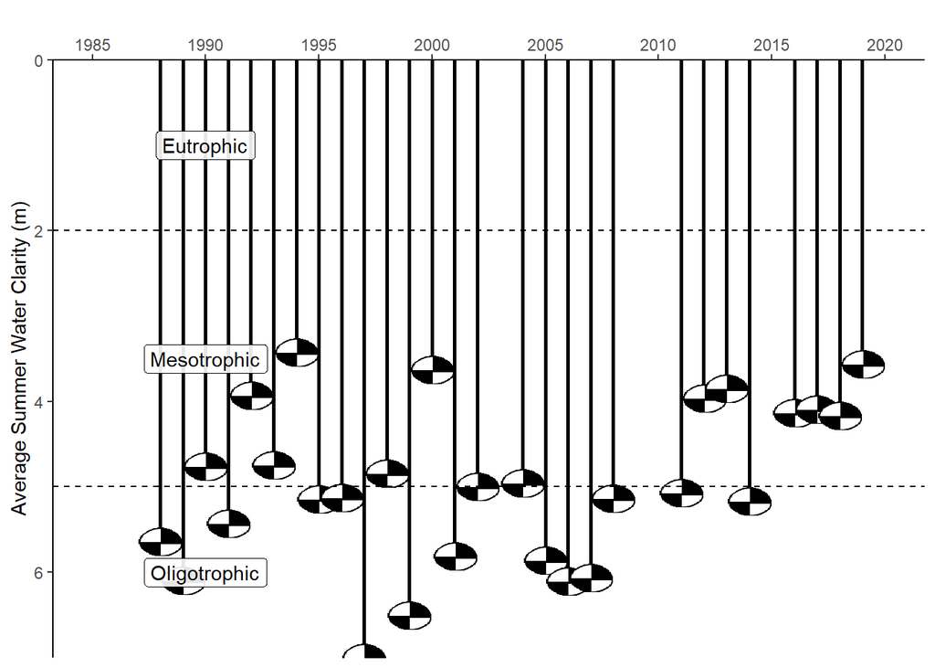

#### Chlorophyll *a*

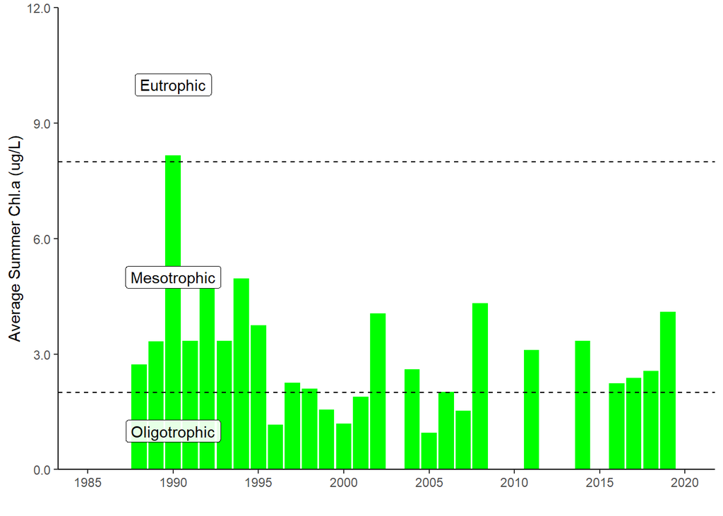

#### Surface and Deep Phosphorus

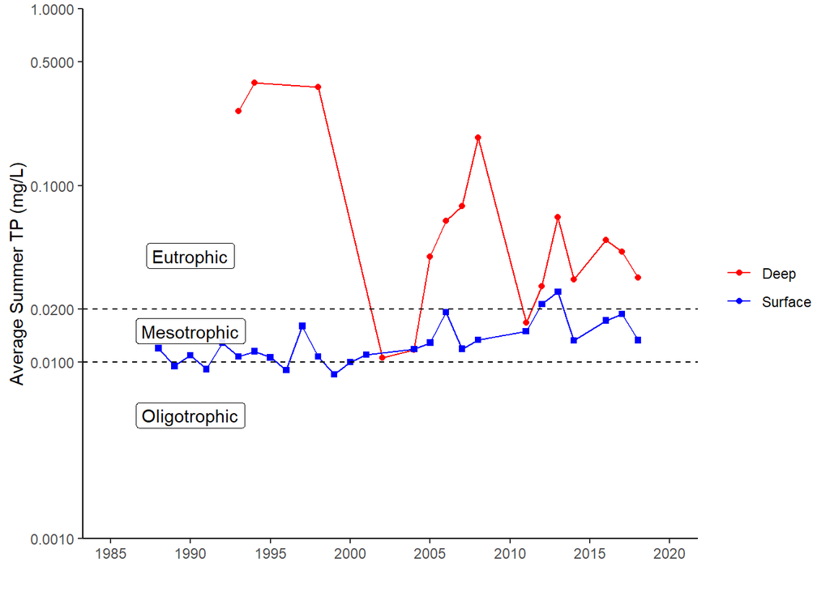

#### Nitrogen

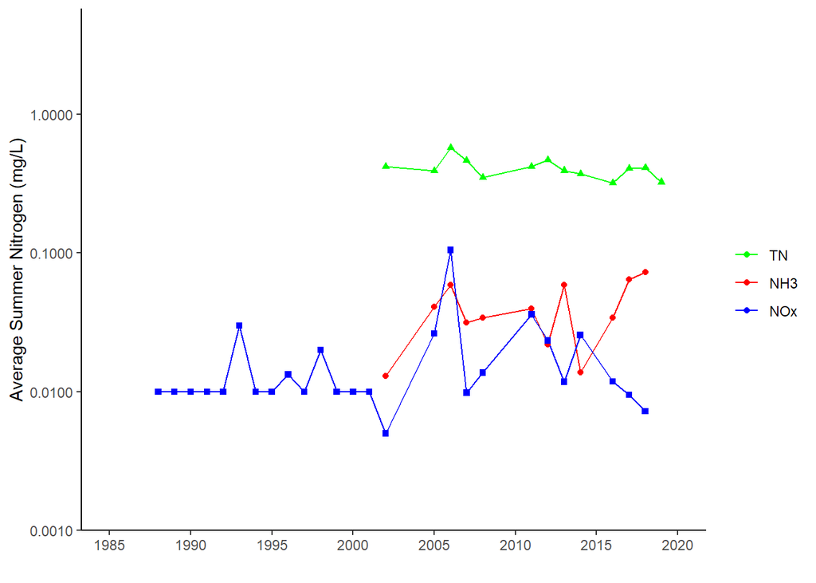

#### TN : TP

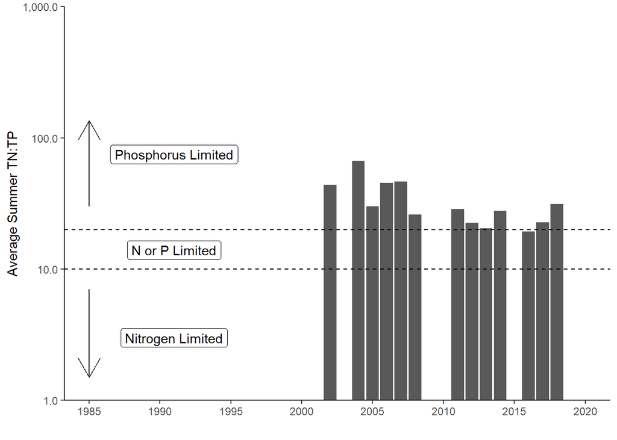

#### pH

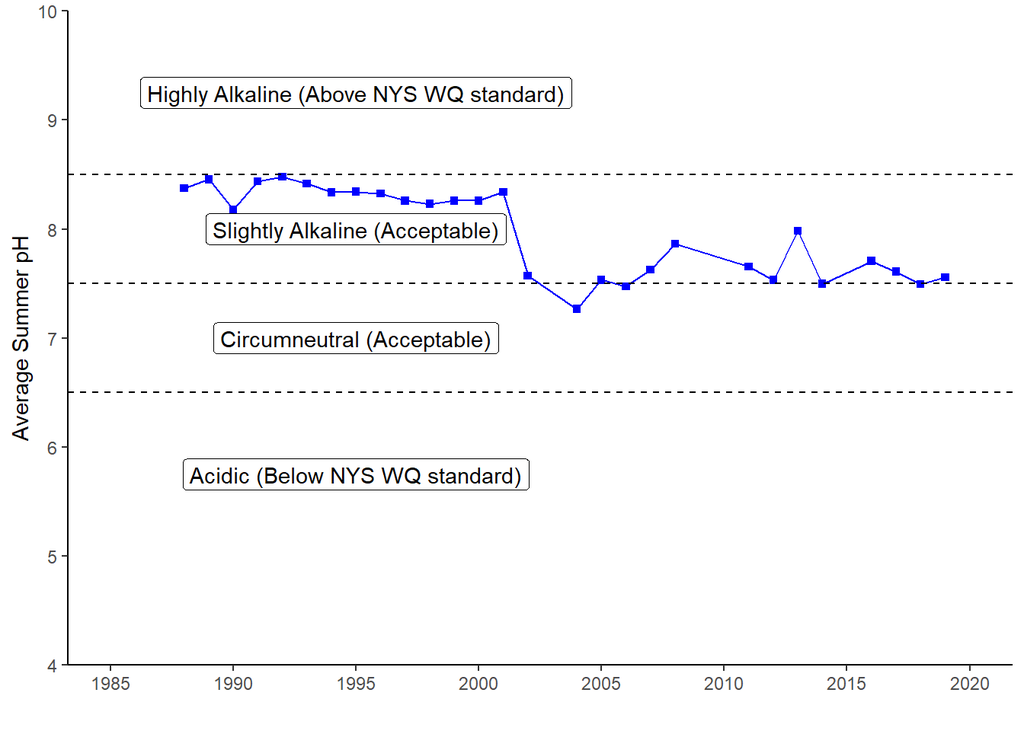

#### Specific Conductance

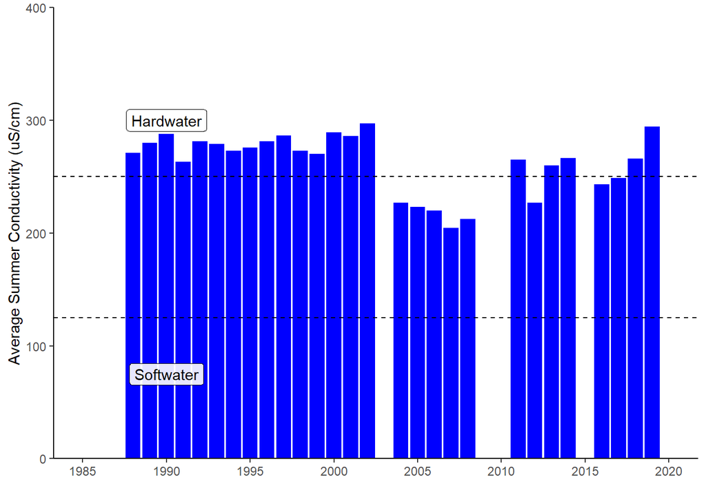

#### Calcium

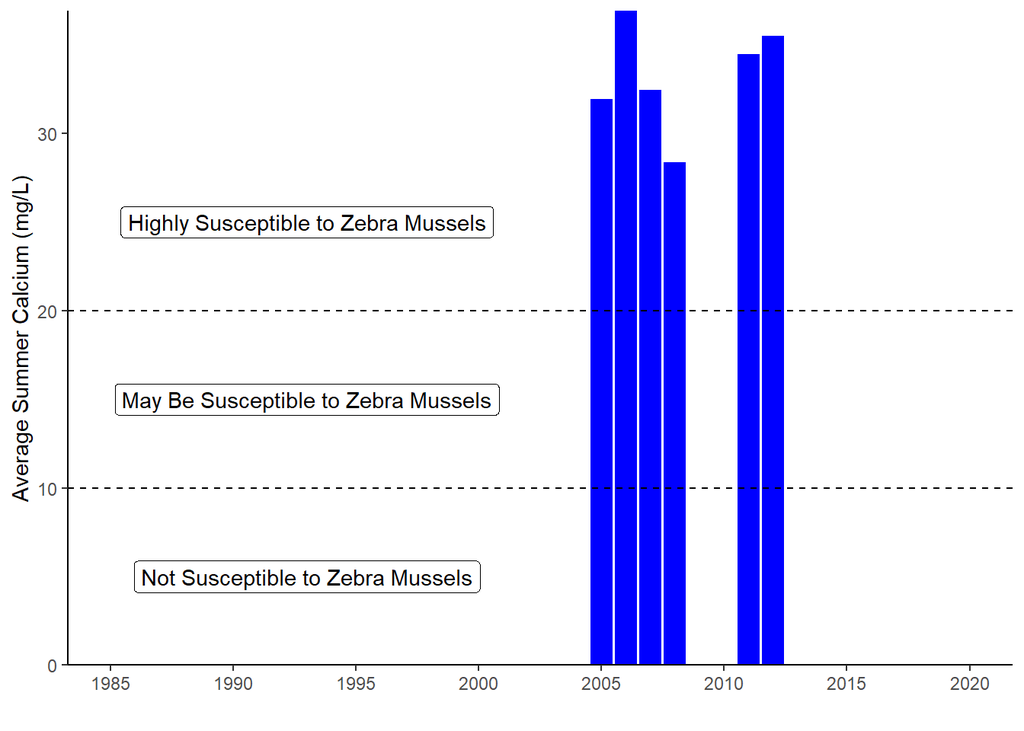

#### Chloride

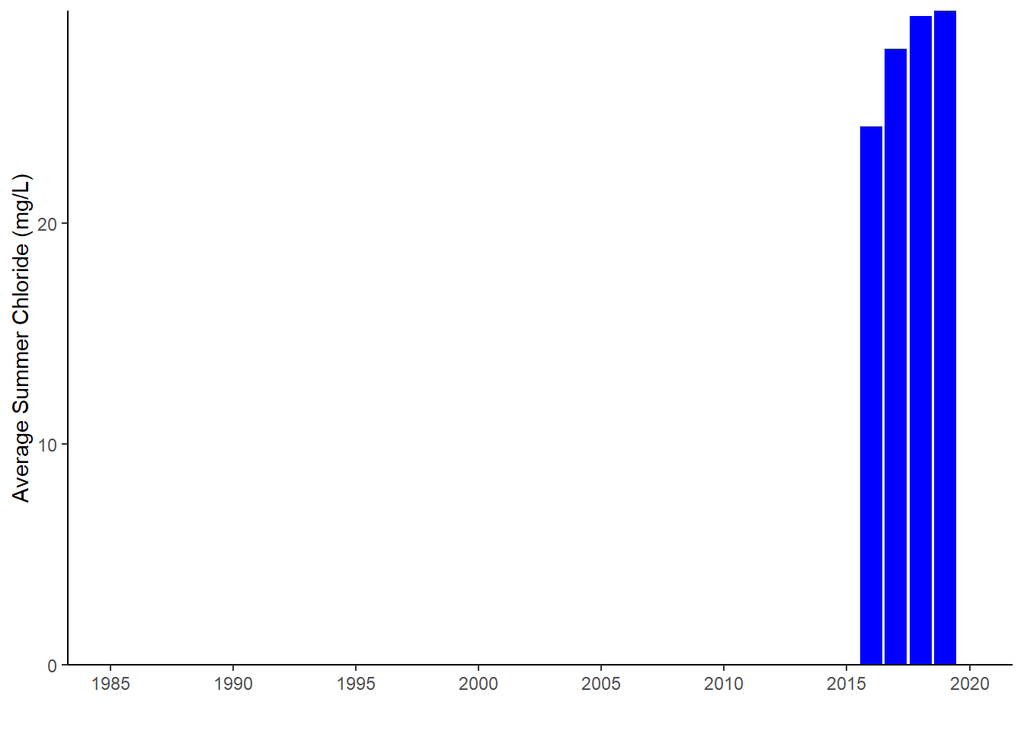

#### Color

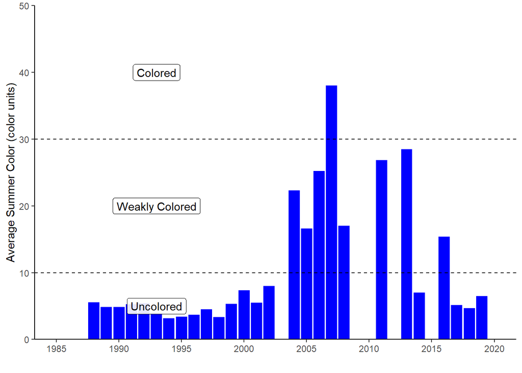

#### Surface and Deep Temperature

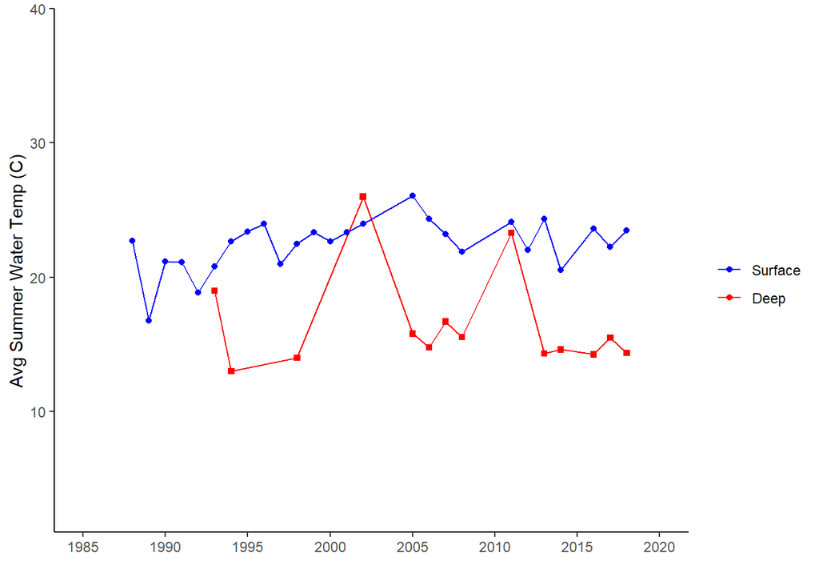

#### Lake Perception

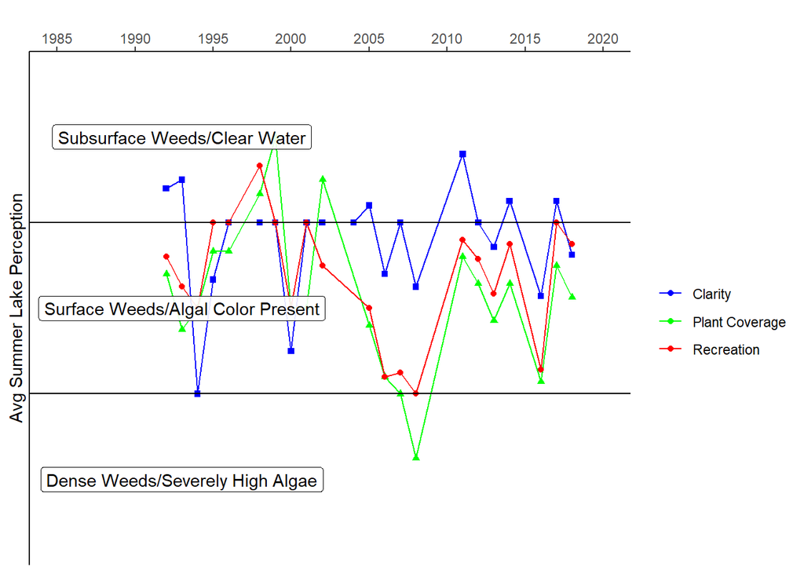